# Content

## 1. Evictions and Code Violations in Philadelphia

In this project, I analyze spatial trends evictions in Philadelphia using data from the [Eviction Lab](https://evictionlab.org/) and building code violations using data from [OpenDataPhilly](https://www.opendataphilly.org/).

Also, I explore the idea that evictions can occur as retaliation against renters for reporting code violations. Spatial correlations between evictions and code violations from the City's Licenses and Inspections department can offer some insight into this question.

## 2. Comparing the NDVI in the city and the suburb

In the second part, based on Landsat image, I compare the median NDVI within the city limits and the immediate suburbs in Philadelphia, calculate the NDVI around street trees in the city and analyzed the vegetation coverage.

**A couple of interesting background readings:**

- [HuffPost article](https://www.huffingtonpost.com/entry/cities-are-starting-to-pay-attention-to-the-eviction-crisis-thats-devastated-poor-tenants_us_5b1a7b21e4b0bbb7a0dbd59e)
- [PlanPhilly article](http://planphilly.com/articles/2018/04/12/philly-landlords-evict-more-people-than-owners-in-other-large-cities)

## 1 Evictions and Code Violations in Philadelphia

## 1.1 Explore Eviction Lab Data

The Eviction Lab built the first national database for evictions: https://evictionlab.org/

### 1.1.1 Read data using `geopandas`

The first step is to read the eviction data by census tract using `geopandas`. The data for all of Pennsylvania by census tract is available in the `data/` folder in a GeoJSON format.

Load the data file "PAtracts.geojson" using `geopandas`

```python
import pandas as pd
import geopandas as gpd
import numpy as np
from matplotlib import pyplot as plt
import cartopy.crs as csr
import geopandas as gpd
import hvplot.pandas
import rasterio as rio
from rasterio.mask import mask
from rasterstats import zonal_stats
from mpl_toolkits.axes_grid1 import make_axes_locatable
pd.options.display.max_columns = 999
```

```python
evictions = gpd.read_file("./data/PAtracts.geojson")
```

### 1.1.2 Explore and trim the data

Trim data to Philadelphia only.

The data dictionary for the descriptions of the various columns in top-level repository folder: `eviction_lab_data_dictionary.txt`

**Note:** the column names are shortened — see the end of the above file for the abbreviations. The numbers at the end of the columns indicate the years. For example, `e-16` is the number of evictions in 2016.

```python
is_philly=evictions['pl']=='Philadelphia County, Pennsylvania'
philly_evictions = evictions[is_philly]
philly_evictions.head()
```

|  | GEOID | west | south | east | north | n | pl | p-00 | pr-00 | roh-00 | pro-00 | mgr-00 | mhi-00 | mpv-00 | rb-00 | pw-00 | paa-00 | ph-00 | pai-00 | pa-00 | pnp-00 | pm-00 | po-00 | ef-00 | e-00 | er-00 | efr-00 | lf-00 | imputed-00 | … |
| --- | --- | --- | --- | --- | --- | --- | --- | --- | --- | --- | --- | --- | --- | --- | --- | --- | --- | --- | --- | --- | --- | --- | --- | --- | --- | --- | --- | --- | --- | --- |
| 435 | 42101000100 | -75.1523 | 39.9481 | -75.1415 | 39.9569 | 1 | Philadelphia County, Pennsylvania | 2646.71 | 9.26 | 1347.0 | 77.12 | 959.0 | 48886.0 | 189700.0 | 24.5 | 78.45 | 12.42 | 3.47 | 0.23 | 3.92 | 0.00 | 1.40 | 0.11 | NaN | NaN | NaN | NaN | 0.0 | 0.0 | … |
| 436 | 42101000200 | -75.1631 | 39.9529 | -75.1511 | 39.9578 | 2 | Philadelphia County, Pennsylvania | 1362.00 | 56.42 | 374.0 | 81.48 | 421.0 | 8349.0 | 55600.0 | 31.2 | 11.16 | 5.21 | 1.69 | 0.07 | 79.59 | 0.07 | 2.20 | 0.00 | NaN | NaN | NaN | NaN | 0.0 | 0.0 | … |
| 437 | 42101000300 | -75.1798 | 39.9544 | -75.1623 | 39.9599 | 3 | Philadelphia County, Pennsylvania | 2570.00 | 12.16 | 861.0 | 69.49 | 688.0 | 40625.0 | 233900.0 | 29.0 | 70.86 | 14.67 | 3.81 | 0.27 | 7.00 | 0.08 | 3.04 | 0.27 | NaN | NaN | NaN | NaN | 0.0 | 0.0 | … |
| 438 | 42101000801 | -75.1833 | 39.9486 | -75.1773 | 39.9515 | 8.01 | Philadelphia County, Pennsylvania | 1478.00 | 14.40 | 810.0 | 73.65 | 933.0 | 42346.0 | 265200.0 | 27.6 | 81.67 | 2.97 | 3.50 | 0.04 | 10.08 | 0.04 | 1.26 | 0.45 | NaN | NaN | NaN | NaN | 0.0 | 0.0 | … |
| 439 | 42101000804 | -75.1712 | 39.9470 | -75.1643 | 39.9501 | 8.04 | Philadelphia County, Pennsylvania | 3301.00 | 14.40 | 2058.0 | 73.65 | 933.0 | 42346.0 | 265200.0 | 27.6 | 81.67 | 2.97 | 3.50 | 0.04 | 10.08 | 0.04 | 1.26 | 0.45 | NaN | NaN | NaN | NaN | 0.0 | 0.0 | … |

### 1.1.3 Transform from wide to tidy format

Use the `pd.melt()` function to transform the eviction data into tidy format, using the number of evictions from **2003 to 2016**.

The tidy data frame should have four columns: `GEOID`, `geometry`, a column holding the number of evictions, and a column telling you what the name of the original column was for that value.

```python
value_vars = ["e-%02d" % x for x in range(3, 17)]
data = pd.melt(
    philly_evictions,
    id_vars=["GEOID", "geometry"],
    value_vars=value_vars,
    value_name="evictions",
    var_name='year'
)
data.head()
```

|  | GEOID | geometry | year | evictions |
| --- | --- | --- | --- | --- |
| 0 | 42101000100 | MULTIPOLYGON (((-75.14161 39.95549, -75.14163 ... | e-03 | 21.0 |
| 1 | 42101000200 | MULTIPOLYGON (((-75.15122 39.95686, -75.15167 ... | e-03 | 3.0 |
| 2 | 42101000300 | MULTIPOLYGON (((-75.16234 39.95782, -75.16237 ... | e-03 | 17.0 |
| 3 | 42101000801 | MULTIPOLYGON (((-75.17732 39.95096, -75.17784 ... | e-03 | 13.0 |
| 4 | 42101000804 | MULTIPOLYGON (((-75.17118 39.94778, -75.17102 ... | e-03 | 21.0 |

### 1.1.4 The number of evictions across Philadelphia

Use `hvplot()` to generate a choropleth showing the number of evictions for a specified year, with a widget dropdown to select a given year.

```python
from bokeh.resources import INLINE

data['year'] = data['year'].str.replace('e-', '20')
number_of_evictions = data.groupby(['year']).sum()

plot=data.hvplot(
    c="evictions",
    groupby="year",
    dynamic=False,
    frame_width=300,
    frame_height=300,
    cmap="Plasma",
    title='Evictions across Philadelphia of each year'
)
plot
```

[interactive chart not shown]

## 1.2 Code Violations in Philadelphia

Explore data for code violations from the Licenses and Inspections Department of Philadelphia to look for potential correlations with the number of evictions.

### 1.2.1 Load data from 2012 to 2016

L+I violation data for years including 2012 through 2016 (inclusive) is provided in a CSV format in the "data/" folder.

Load the data using pandas and convert to a GeoDataFrame.

```python
li_data = pd.read_csv('./data/li_violations.csv')

li_data['geometry'] = gpd.points_from_xy(li_data.lng, li_data.lat)
li_data = gpd.GeoDataFrame(li_data, geometry='geometry', crs="EPSG:4326")
li_data.head()
```

|  | lat | lng | violationdescription | geometry |
| --- | --- | --- | --- | --- |
| 0 | 40.050526 | -75.126076 | CLIP VIOLATION NOTICE | POINT (-75.12608 40.05053) |
| 1 | 40.050593 | -75.126578 | LICENSE-CHANGE OF ADDRESS | POINT (-75.12658 40.05059) |
| 2 | 40.050593 | -75.126578 | LICENSE-RES SFD/2FD | POINT (-75.12658 40.05059) |
| 3 | 39.991994 | -75.128895 | EXT A-CLEAN WEEDS/PLANTS | POINT (-75.12889 39.99199) |
| 4 | 40.023260 | -75.164848 | EXT A-VACANT LOT CLEAN/MAINTAI | POINT (-75.16485 40.02326) |

### 1.2.2 Trim to specific violation types

There are many different types of code violations (running the `nunique()` function on the `violationdescription` column will extract all of the unique ones). More information on different types of violations can be found [on the City's website](https://www.phila.gov/li/codesandregulations/Pages/codes.aspx).

Below, I select 15 types of violations that deal with property maintenance and licensing issues. The goal is to see if these kinds of violations are correlated spatially with the number of evictions in a given area.

```python
violation_types = [
    "INT-PLMBG MAINT FIXTURES-RES",
    "INT S-CEILING REPAIR/MAINT SAN",
    "PLUMBING SYSTEMS-GENERAL",
    "CO DETECTOR NEEDED",
    "INTERIOR SURFACES",
    "EXT S-ROOF REPAIR",
    "ELEC-RECEPTABLE DEFECTIVE-RES",
    "INT S-FLOOR REPAIR",
    "DRAINAGE-MAIN DRAIN REPAIR-RES",
    "DRAINAGE-DOWNSPOUT REPR/REPLC",
    "LIGHT FIXTURE DEFECTIVE-RES",
    "LICENSE-RES SFD/2FD",
    "ELECTRICAL -HAZARD",
    "VACANT PROPERTIES-GENERAL",
    "INT-PLMBG FIXTURES-RES",
]
```

```python
df = li_data.loc[li_data['violationdescription'].isin(violation_types)]
tracts = philly_evictions[['GEOID', 'geometry']]
tracts = tracts.to_crs(epsg=3857)
```

### 1.2.3 Make a hex bin map

The code violation data is **point data**. We can get a quick look at the geographic distribution using `matplotlib` and the `hexbin()` function. Make a hex bin map of the code violations and overlay the census tract outlines.

```python
from mpl_toolkits.axes_grid1 import make_axes_locatable
```

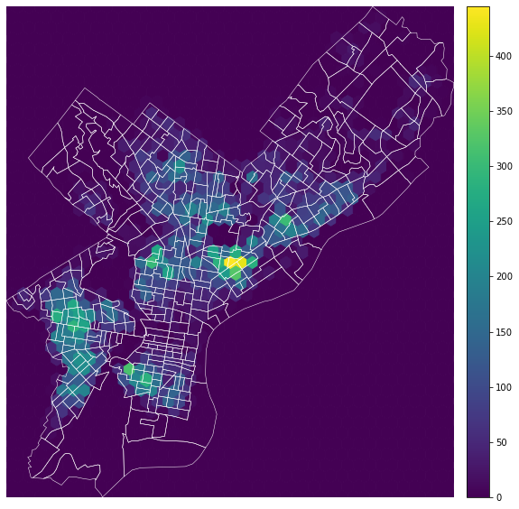

```python
# Initialize a new figure
fig, ax = plt.subplots(figsize=(10, 10))

# Create a nice, lined up colorbar axes (called "cax" here)
divider = make_axes_locatable(ax)
cax = divider.append_axes("right", size="5%", pad=0.2)

# Get bounds of tracts
xmin, ymin, xmax, ymax = tracts.to_crs(epsg=3857).total_bounds
extent = [xmin, xmax, ymin, ymax]

# Convert to Web Mercator and plot the hexbins
X = df.to_crs(epsg=3857)
img = ax.hexbin(
    X.geometry.x, X.geometry.y, gridsize=40, mincnt=0, cmap="viridis", extent=extent
)
plt.colorbar(img, cax=cax)

# Overlay the ZIP codes on the same axes
tracts.to_crs(epsg=3857).plot(ax=ax, facecolor="none", linewidth=0.5, edgecolor="white")

# Set xlims and ylims
ax.set_xlim(xmin, xmax)
ax.set_ylim(ymin, ymax)

# Turn axis off
ax.set_aspect("equal")
ax.set_axis_off()
```

### 1.2.4 Spatially join data sets

```python
# Conver to the same CRS
tracts = tracts.to_crs(epsg=4326)
df = df.to_crs(epsg=4326)
joined = gpd.sjoin(df, tracts[['geometry', 'GEOID']], how='left', op='within')
```

### 1.2.5 Calculate the number of violations by type per census tract

Find the number of violations (for each kind) per census tract.

The result of this step should be a data frame with three columns: `violationdescription`, `GEOID`, and `N`, where `N` is the number of violations of that kind in the specified census tract.

```python
N = joined.groupby(['GEOID', 'violationdescription']).size()
N = N.unstack(fill_value=0).stack().reset_index(name='N')
```

### 1.2.6 Merge with census tracts geometries

```python
N = tracts.merge(N, how='left', on='GEOID')
```

### 1.2.7 Interactive choropleths for each violation type

Use `hvplot()` to create an interactive choropleth for each violation type and add a widget to specify different violation types.

```python
plot=N.hvplot(
    c="N",
    frame_width=300,
    frame_height=300,
    groupby="violationdescription",
    cmap="Plasma",
    dynamic=False,
    title='Eviction number of each violation type'
)

hvplot.save(plot, 'test.html')

from IPython.display import HTML
HTML(filename='test.html')
```

[interactive chart not shown]

## Part 2: Exploring the NDVI in Philadelphia

Normalized difference vegetation index (NDVI) is a simple graphical indicator that can be used to analyze remote sensing measurements, assessing whether or not the target being observed contains live green vegetation.

In this part, I compare the median NDVI within the city limits and the immediate suburbs; and calculate the NDVI around street trees in the city.

## 2.1 Comparing the NDVI in the city and the suburbs

### 2.1.1 Load Landsat data for Philadelphia

Use rasterio to load the landsat data for Philadelphia (available in the "data/" folder)

```python
import rasterio as rio
import numpy as np
landsat = rio.open("./data/landsat8_philly.tif")
```

### 2.1.2 Separating the city from the suburbs

Create two polygon objects, one for the city limits and one for the suburbs. To calculate the suburbs polygon, I take everything outside the city limits but still within the bounding box.

```python
city_limits = gpd.read_file("data/City_Limits.geojson")

suburbs = city_limits.envelope.difference(city_limits)

city_limits = city_limits.to_crs(landsat.crs.data)
suburbs = suburbs.to_crs(landsat.crs.data)
#philly_raster=philly.to_crs(epsg=32618)
#b=city_limits.envelope
suburbs.squeeze()
```

### 2.1.3 Mask and calculate the NDVI for the city and the suburbs

Using the two polygons from the last section and rasterio's mask functionality to create two masked arrays from the landsat data, one for the city and one for the suburbs.

For each masked array, calculate the NDVI.

```python
from rasterio.mask import mask
```

```python
masked_city, _ = mask(
    dataset=landsat,
    shapes=city_limits.geometry,
    crop=True, # remove pixels not within boundary
    all_touched=True, # get all pixels that touch the boudnary
    filled=False # do not fill cropped pixels with a default value
)

masked_suburbs, _ = mask(
    dataset=landsat,
    shapes=suburbs.geometry,
    crop=True, # remove pixels not within boundary
    all_touched=True, # get all pixels that touch the boudnary
    filled=False # do not fill cropped pixels with a default value
)
```

```python
def calculate_NDVI(nir, red):
    """
    Calculate the NDVI from the NIR and red landsat bands
    """

    # Convert to floats
    nir = nir.astype(float)
    red = red.astype(float)

    # Get valid entries
    check = np.logical_and( red.mask == False, nir.mask == False )

    # Where the check is True, return the NDVI, else return NaN
    ndvi = np.where(check,  (nir - red ) / ( nir + red ), np.nan )
    return ndvi
```

```python
city_NDVI = calculate_NDVI(masked_city[4], masked_city[3])
suburbs_NDVI = calculate_NDVI(masked_suburbs[4], masked_suburbs[3])
```

### 2.1.4 Calculate the median NDVI within the city and within the suburbs

```python
median_NDVI_city = np.nanmedian(city_NDVI)
median_NDVI_suburbs = np.nanmedian(suburbs_NDVI)
```

```python
print("Median NDVI within the city limits = ", median_NDVI_city)
print("Median NDVI within the suburbs = ", median_NDVI_suburbs)
```

```
Median NDVI within the city limits =  0.20268593532493442
Median NDVI within the suburbs =  0.37466958688920776
```

## 2.2 Calculating the NDVI for Philadelphia's street treets

### 2.2.1 Load the street tree data

The data is available in the "data/" folder. It has been downloaded from [OpenDataPhilly](https://www.opendataphilly.org/dataset/ppr-tree-canopy). It contains the locations of abot 2,500 street trees in Philadelphia.

```python
street_trees = gpd.read_file("./data/ppr_tree_canopy_points_2015.geojson").to_crs(landsat.crs.data)
street_trees.head()
```

[output not shown]

### 2.2.2 Calculate the NDVI values at the locations of the street trees

- Use the rasterstats package to calculate the NDVI values at the locations of the street trees.
- Since these are point geometries, we can calculate either the median or the mean statistic (only one pixel will contain each point).

```python
from rasterstats import zonal_stats
stats = zonal_stats(street_trees, city_NDVI, affine=landsat.transform, stats=['mean', 'median'])
```

### 2.2.3 Plotting the results

The following plots are:

1. A histogram of the NDVI values, using matplotlib's `hist` function. Include a vertical line that marks the NDVI = 0 threshold
2. A plot of the street tree points, colored by the NDVI value, using geopandas' `plot` function. Include the city limits boundary on your plot.

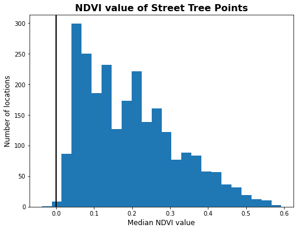

```python
street_trees['median_NDVI'] = [s['median'] for s in stats]

fig, ax = plt.subplots(figsize=(8,6))

# Plot histogram
ax.hist(street_trees['median_NDVI'], bins='auto')

ax.axvline(x=0, c='k', lw=2)

ax.set_title(
    "NDVI value of Street Tree Points", weight="bold", fontsize=16
)

# Format
ax.set_xlabel("Median NDVI value", fontsize=12)
ax.set_ylabel("Number of locations", fontsize=12);
```

[figure not shown]

```python
# Initialize
fig, ax = plt.subplots(figsize=(10,10))

# Create a nice, lined up colorbar axes
divider = make_axes_locatable(ax)
cax = divider.append_axes("right", size="5%", pad=0.2)

# Plot the city limits
city_limits.plot(ax=ax, edgecolor='black', facecolor='none', linewidth=4)

# Plot the median NDVI
street_trees.plot(cax=cax, ax=ax, column='median_NDVI', legend=True, markersize=100, marker='.')

# Format
ax.set_axis_off()
ax.set_title("NDVI values at the locations of the street trees", fontdict={"size": "20"})
```

## 2.2.4 Conclusion

According to the caculation and plots above, we can clearly the suburb areas have higher NDVI than urban areas. Thus, we can conclude that there is wider vegetation coverage in suburb areas.